# Quantium Virtual Internship - Retail Strategy and Analytics - Task 1

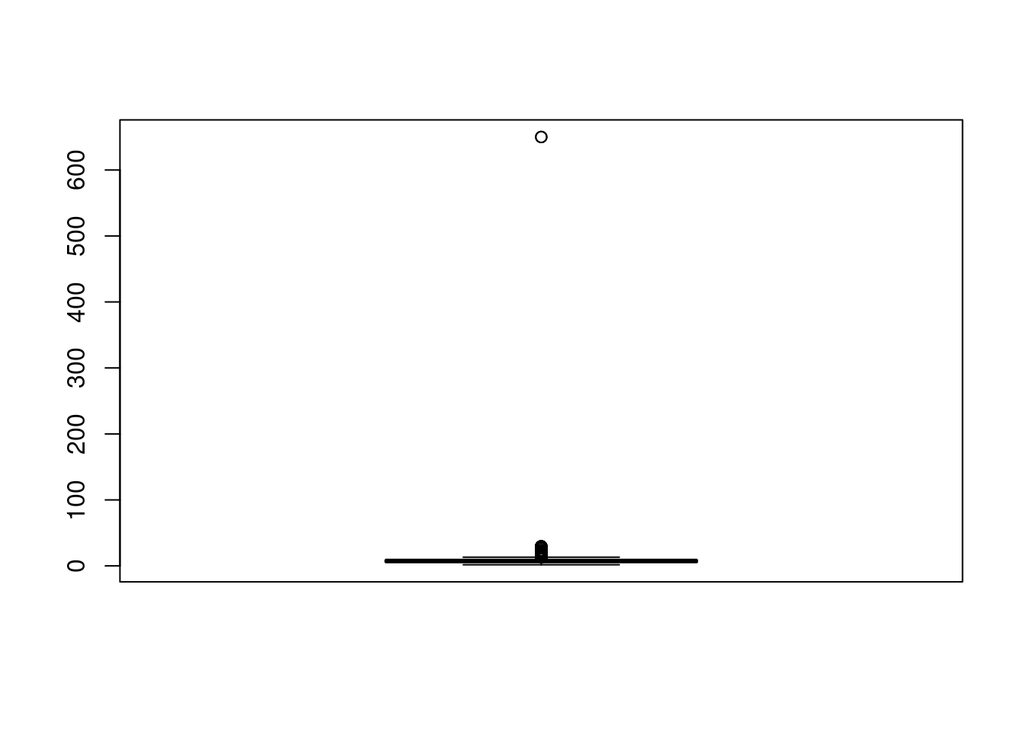

```r
# Create a boxplot to check for outliers
boxplot(transactionData$TOT_SALES)
```

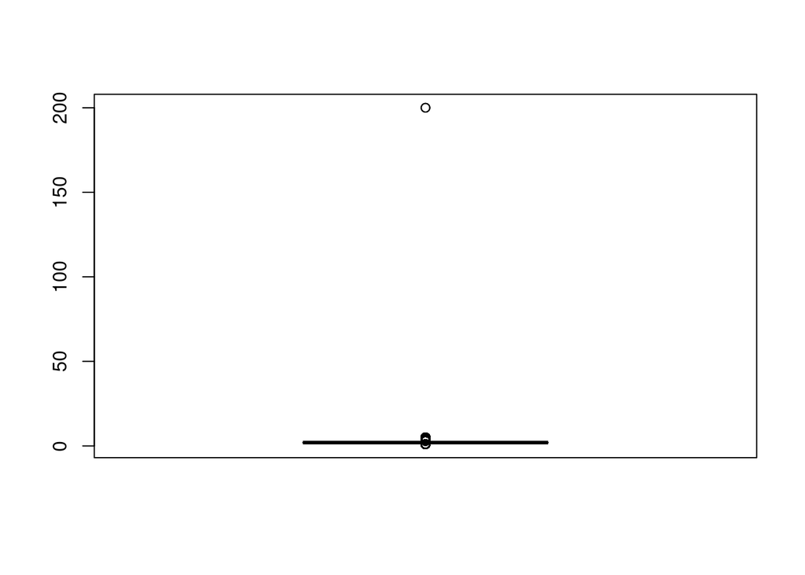

```r
boxplot(transactionData$PROD_QTY)
```

There are no nulls in the columns but product quantity appears to have an outlier which we should investigate further. Let’s investigate further the case where 200 packets of chips are bought in one transaction.

```r
#### Filter the dataset to find the outlier
# Over to you! Use a filter to examine the transactions in question.
transactionData_filtered <- transactionData[transactionData$PROD_QTY == 200, ]
```

There are two transactions where 200 packets of chips are bought in one transaction and both of these transactions were by the same customer.

```r
#### Let's see if the customer has had other transactions
# Over to you! Use a filter to see what other transactions that customer made.
transactionData_filtered
```

```
##          DATE STORE_NBR LYLTY_CARD_NBR TXN_ID PROD_NBR
## 1: 2018-08-19       226         226000 226201        4
## 2: 2019-05-20       226         226000 226210        4
##                           PROD_NAME PROD_QTY TOT_SALES
## 1: Dorito Corn Chp     Supreme 380g      200       650
## 2: Dorito Corn Chp     Supreme 380g      200       650
```

```r
transactionData_filtered1 <- transactionData[transactionData$LYLTY_CARD_NBR == 226000, ]
transactionData_filtered1
```

```
##          DATE STORE_NBR LYLTY_CARD_NBR TXN_ID PROD_NBR
## 1: 2018-08-19       226         226000 226201        4
## 2: 2019-05-20       226         226000 226210        4
##                           PROD_NAME PROD_QTY TOT_SALES
## 1: Dorito Corn Chp     Supreme 380g      200       650
## 2: Dorito Corn Chp     Supreme 380g      200       650
```

It looks like this customer has only had the two transactions over the year and is not an ordinary retail customer. The customer might be buying chips for commercial purposes instead. We’ll remove this loyalty card number from further analysis.

```r
#### Filter out the customer based on the loyalty card number
# Over to you!
#### Re-examine transaction data
# Over to you!
# Remove rows where LYLTY_CARD_NBR is equal to 226000
transactionData <- transactionData[transactionData$LYLTY_CARD_NBR != 226000, ]
# View the modified data frame
str(transactionData)
```

```
## Classes 'data.table' and 'data.frame': 246740 obs. of 8 variables:
## $ DATE : Date, format: "2018-10-17" "2019-05-14" ...
## $ STORE_NBR : int 1 1 1 2 2 4 4 5 7 7 ...
## $ LYLTY_CARD_NBR: int 1000 1307 1343 2373 2426 4149 4196 5026 7150 7215 ...
## $ TXN_ID : int 1 348 383 974 1038 3333 3539 4525 6900 7176 ...
## $ PROD_NBR : int 5 66 61 69 108 16 24 42 52 16 ...
## $ PROD_NAME : chr "Natural Chip Compny SeaSalt175g" "CCs Nacho Cheese 175g"
"Smiths Crinkle Cut Chips Chicken 170g" "Smiths Chip Thinly S/Cream&Onion 175g"
...
## $ PROD_QTY : int 2 3 2 5 3 1 1 1 2 1 ...
## $ TOT_SALES : num 6 6.3 2.9 15 13.8 5.7 3.6 3.9 7.2 5.7 ...
## - attr(*, ".internal.selfref")=<externalptr>
```

That’s better. Now, let’s look at the number of transaction lines over time to see if there are any obvious data issues such as missing data.

```r
#### Count the number of transactions by date
# Over to you! Create a summary of transaction count by date.
# Convert date column to a Date object
transactionData$DATE <- as.Date(transactionData$DATE, format = "%Y-%m-%d")

# Aggregate transaction count by date
transactions_by_date <- aggregate(x = list(count = transactionData$TXN_ID),
                                   by = list(date = transactionData$DATE),
                                   FUN = length)

# Print the summary
print(transactions_by_date)
```

```
##           date count
## 1   2018-07-01   663
## 2   2018-07-02   650
## 3   2018-07-03   674
## 4   2018-07-04   669
## 5   2018-07-05   660
## 6   2018-07-06   711
## 7   2018-07-07   695
## 8   2018-07-08   653
## 9   2018-07-09   692
## 10  2018-07-10   650
## 11  2018-07-11   701
## 12  2018-07-12   717
## 13  2018-07-13   727
## 14  2018-07-14   661
```

[output cut: 350 more lines]

There’s only 364 rows, meaning only 364 dates which indicates a missing date. Let’s create a sequence of dates from 1 Jul 2018 to 30 Jun 2019 and use this to create a chart of number of transactions over time to find the missing date.

```r
#### Create a sequence of dates and join this the count of transactions by date
# Over to you - create a column of dates that includes every day from 1 Jul 2018 to 30 Jun 2019, and join it onto the data to fill in the missing day.
# Generate a sequence of dates from 1 Jul 2018 to 30 Jun 2019
date_seq <- seq(from = as.Date("2018-07-01"), to = as.Date("2019-06-30"), by = "day")

# Create a data frame with the date sequence
date_df <- data.frame(DATE = date_seq)

# Join the date_df to transaction_by_date to fill in the missing days
transactions_by_day <- merge(date_df, transactions_by_date, all = TRUE)
```

```r
library(dplyr)

# Rename the "date" column to "transaction_date" in transaction_by_day
transactions_by_day <- transactions_by_day %>% rename(transaction_date = date)

# Merge transaction_by_day with date_df to fill in the missing dates
transactions_by_day_filled <- merge(date_df, transactions_by_day, all.x = TRUE)

# Print the summary of transaction count by date with missing days filled in
head(transactions_by_day_filled)
```

```
##         DATE transaction_date count
## 1 2018-07-01       2018-07-01   663
## 2 2018-07-01       2018-07-02   650
## 3 2018-07-01       2018-07-04   669
## 4 2018-07-01       2018-07-05   660
## 5 2018-07-01       2018-07-07   695
## 6 2018-07-01       2018-07-10   650
```